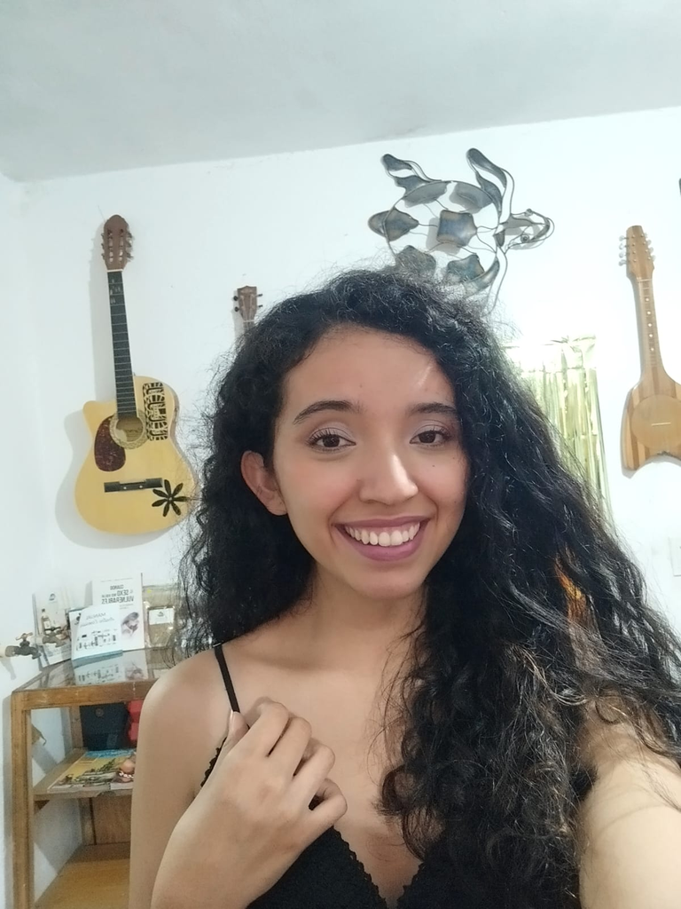

# Miryam Zamora Jiménez

## Bio

Miryam Zamora Jimenez es estudiante de Ciencias Genómicas en la Universidad Nacional Autónoma de México (UNAM), con formación interdisciplinaria en biología molecular, bioinformática, genética y análisis computacional de datos genómicos. Cuenta con experiencia en el análisis de datos genómicos, y desarrollo de scripts en Python y R para los mismos. Interesada en la ciencia abierta y la divulgación científica, buscando siempre contribuir a la comunidad científica y a la sociedad en general a través de su trabajo.

## Education

**Universidad Nacional Autónoma de México** | Ciudad de México, México

Licenciatura en Ciencias Genómicas | Agosto 2024 - Presente

## Sobre Mí

Soy una persona a la que le apasiona la ciencia, la tecnología y la innovación. Me encanta aprender cosas nuevas y enfrentar desafíos en el proceso, así como compartir y hacer la ciencia accesible para la sociedad en general. Me considero una persona creativa, curiosa y divertida, siempre buscando nuevas formas de abordar los problemas y encontrar soluciones innovadoras. Me gusta trabajar en equipo y colaborar con otros para lograr objetivos comunes.

## Hobbies

- Me encantan las danzas polinesias, especialmente el hawaiano y el tahitiano, disfruto mucho bailar, expresarme y aprender sobre la cultura a través de la danza.